# **Analysis of Low Birthweight Children** TODO - LINK TABLE OF CONENTS AS IN EXAMPLE

# Results of Data Exploration

Analysis of variables

### **Target Variable**

LOW Low birth weight (0: >= 2500, 1: < 2500 g)

### **Retained**

**AGE** Mother’s age in years

**RACE** Race (1: White, 2: Black, 3: Other)

**FTV** Number of physician visits during the first trimester (1: None, 2: One, 3: Two, etc)

### **Excluded**

**PTL** History of premature labor (1: None, 2: One, 3: Two, etc)

**HT** History of hypertension (1: No, 2: Yes)

**UI** Presence of Uterine irritability (1: No, 2: Yes)

**ID** Identification Code

# PARSE DATA

Note if another user is running this notebook they will need to replace the 'bucket' information of the data found in the second agrument of the 1 line below. The below code reads the data into a SPARK RDD and returns the first 5 rows, as well as the total number of rows.

Note that the number of rows returned includes the header row.

```python
data = sc.textFile(cos.url('lowbwt.csv', 'apachesparktutorial-donotdelete-pr-pgzvvm467lbdus'))
print ("Total records in the data set:", data.count())
print ("The first 5 rows")
data.take(5)
```

```
Total records in the data set: 190
The first 5 rows
```

```
['ID,LOW,AGE,RACE,SMOKE,PTL,HT,UI,FTV',
 '85,0,19,2,0,0,0,1,0',
 '86,0,33,3,0,0,0,0,3',
 '87,0,20,1,1,0,0,0,1',
 '88,0,21,1,1,0,0,1,2']
```

```python
#Parse and Load the data into a dataframe. The code calls the parsing function defined above
documents = data.filter(lambda s: "Name" not in s).map(parseDocument)
BWTData = documents.toDF() # ToDataFrame
print ("Number of records: " + str(BWTData.count()))
print ( "First 5 records: ")
BWTData.take(5)
```

[output not shown]

```
Number of records: 190
First 5 records:
```

```
[Row(ID='PTL', MotherInfo='AGE RACE SMOKE FTV', label=1.0),
 Row(ID='0', MotherInfo='19 2 0 0', label=0.0),
 Row(ID='0', MotherInfo='33 3 0 3', label=0.0),
 Row(ID='0', MotherInfo='20 1 1 1', label=0.0),
 Row(ID='0', MotherInfo='21 1 1 2', label=0.0)]
```

# Split Data into Training and Test Set

Standard seperation into training and test set at 80% training and 20% test.

```python
# Divide the data into training and test set
(train, test) = BWTData.randomSplit([0.8, 0.2])
print ("Number of records in the training set: " + str(train.count()))
print ("Number of records in the test set: " + str(test.count()))
# Output first 20 records in the training set
print ("First 20 records in the training set: ")
train.show()
```

```
Number of records in the training set: 145
Number of records in the test set: 45
First 20 records in the training set:
+---+----------+-----+
| ID|MotherInfo|label|
+---+----------+-----+
|  0|  15 2 0 0|  0.0|
|  0|  16 1 1 0|  0.0|
|  0|  16 2 0 0|  0.0|
|  0|  17 1 1 0|  0.0|
|  0|  17 3 0 0|  0.0|
|  0|  17 3 0 0|  0.0|
|  0|  17 3 0 1|  0.0|
|  0|  17 3 1 0|  0.0|
|  0|  18 1 1 0|  0.0|
|  0|  18 1 1 0|  0.0|
|  0|  18 1 1 0|  0.0|
|  0|  18 2 0 0|  0.0|
|  0|  19 1 1 0|  0.0|
|  0|  19 2 0 0|  0.0|
|  0|  19 3 0 0|  0.0|
|  0|  19 3 0 0|  0.0|
|  0|  19 3 0 0|  0.0|
|  0|  19 3 0 0|  0.0|
|  0|  20 1 1 1|  0.0|
|  0|  20 3 0 0|  0.0|
+---+----------+-----+
only showing top 20 rows
```

# Construction of Logistic Regression Model

Using SPARKMl pipeline to build a standard logistic regression model

**Tokenizer** is a unary transformer (applies a transformation to one input column and writes result to another by creating a new column Specifically it converts the column of string values to lowercase and then splits it by white spaces. For example

id |sentence |tokens | +---+-----------------------------+-----------------------------------+ |1 |Hello world! |[hello, world!] | |2 |Here is yet another sentence.|[here, is, yet, another, sentence.]|

More details can be found here --> https://jaceklaskowski.gitbooks.io/mastering-apache-spark/spark-mllib/spark-mllib-transformers-Tokenizer.html

**hasingTF** - Is an efficient way to hash the data to reduce memory and computational overhead.

```python
tokenizer = Tokenizer(inputCol="MotherInfo", outputCol="words")
hashingTF = HashingTF(inputCol=tokenizer.getOutputCol(), outputCol="features")
lr = LogisticRegression(maxIter=100, regParam=0.01)
pipeline = Pipeline(stages=[tokenizer, hashingTF, lr])
```

```python
##Standard Pipeline, runs our model in the stages defined, first tokenizer, then hash, then the model
#Training on Train Data
# set up Logistic Regression Model
# the stages are executed in order
model = pipeline.fit(train)
```

# Predict on Test Data

```python
#Standard - predicts on test data and prints each one
# Make predictions for test data and print columns of interest
prediction = model.transform(test)
selected = prediction.select("MotherInfo", "prediction", "probability")
for row in selected.collect():
    print (row)

#To aid intepretability i've included the features in the order they are shown in 'MotherInfo'
# 0 AGE Mother’s age in years
# 1 RACE Race (1: White, 2: Black, 3: Other)
# 2 SMOKE Smoking status during pregnancy (1: No, 2: Yes)
# 3 FTV Number of physician visits during the first trimester
```

```
Row(MotherInfo='16 3 0 0', prediction=0.0, probability=DenseVector([0.8491, 0.1509]))
Row(MotherInfo='17 2 0 1', prediction=0.0, probability=DenseVector([0.6326, 0.3674]))
Row(MotherInfo='17 2 0 1', prediction=0.0, probability=DenseVector([0.6326, 0.3674]))
Row(MotherInfo='18 1 1 0', prediction=0.0, probability=DenseVector([0.8573, 0.1427]))
Row(MotherInfo='18 1 1 0', prediction=0.0, probability=DenseVector([0.8573, 0.1427]))
Row(MotherInfo='19 1 0 2', prediction=0.0, probability=DenseVector([0.8173, 0.1827]))
Row(MotherInfo='19 1 1 2', prediction=0.0, probability=DenseVector([0.7813, 0.2187]))
Row(MotherInfo='19 3 0 1', prediction=0.0, probability=DenseVector([0.7973, 0.2027]))
Row(MotherInfo='20 2 1 0', prediction=1.0, probability=DenseVector([0.4085, 0.5915]))
Row(MotherInfo='21 3 1 0', prediction=0.0, probability=DenseVector([0.6603, 0.3397]))
Row(MotherInfo='23 2 0 1', prediction=0.0, probability=DenseVector([0.5654, 0.4346]))
Row(MotherInfo='23 3 0 0', prediction=0.0, probability=DenseVector([0.589, 0.411]))
Row(MotherInfo='28 1 0 0', prediction=0.0, probability=DenseVector([0.814, 0.186]))
Row(MotherInfo='28 3 0 0', prediction=0.0, probability=DenseVector([0.7841, 0.2159]))
Row(MotherInfo='30 3 0 0', prediction=0.0, probability=DenseVector([0.8192, 0.1808]))
Row(MotherInfo='30 3 0 0', prediction=0.0, probability=DenseVector([0.8192, 0.1808]))
Row(MotherInfo='32 1 0 0', prediction=0.0, probability=DenseVector([0.8256, 0.1744]))
Row(MotherInfo='32 1 0 4', prediction=0.0, probability=DenseVector([0.7179, 0.2821]))
Row(MotherInfo='33 1 1 1', prediction=0.0, probability=DenseVector([0.9754, 0.0246]))
Row(MotherInfo='20 3 0 1', prediction=1.0, probability=DenseVector([0.3777, 0.6223]))
Row(MotherInfo='20 1 0 1', prediction=1.0, probability=DenseVector([0.4224, 0.5776]))
Row(MotherInfo='15 3 0 0', prediction=1.0, probability=DenseVector([0.4727, 0.5273]))
Row(MotherInfo='17 2 0 2', prediction=0.0, probability=DenseVector([0.6192, 0.3808]))
Row(MotherInfo='18 3 0 0', prediction=0.0, probability=DenseVector([0.8621, 0.1379]))
Row(MotherInfo='20 1 1 0', prediction=1.0, probability=DenseVector([0.4224, 0.5776]))
Row(MotherInfo='20 3 0 0', prediction=1.0, probability=DenseVector([0.432, 0.568]))
Row(MotherInfo='21 1 1 1', prediction=0.0, probability=DenseVector([0.6514, 0.3486]))
Row(MotherInfo='21 1 1 3', prediction=0.0, probability=DenseVector([0.608, 0.392]))
Row(MotherInfo='22 1 0 0', prediction=0.0, probability=DenseVector([0.9194, 0.0806]))
Row(MotherInfo='22 1 1 1', prediction=0.0, probability=DenseVector([0.8791, 0.1209]))
Row(MotherInfo='23 1 0 1', prediction=0.0, probability=DenseVector([0.5794, 0.4206]))
Row(MotherInfo='23 3 0 1', prediction=0.0, probability=DenseVector([0.5335, 0.4665]))
Row(MotherInfo='26 3 0 0', prediction=0.0, probability=DenseVector([0.5369, 0.4631]))
Row(MotherInfo='26 3 0 0', prediction=0.0, probability=DenseVector([0.5369, 0.4631]))
Row(MotherInfo='27 3 0 0', prediction=1.0, probability=DenseVector([0.4998, 0.5002]))
Row(MotherInfo='28 3 0 0', prediction=0.0, probability=DenseVector([0.7841, 0.2159]))
Row(MotherInfo='33 1 0 1', prediction=0.0, probability=DenseVector([0.9802, 0.0198]))
Row(MotherInfo='34 2 1 0', prediction=0.0, probability=DenseVector([0.7324, 0.2676]))
Row(MotherInfo='14 3 1 0', prediction=1.0, probability=DenseVector([0.466, 0.534]))
Row(MotherInfo='17 3 1 0', prediction=0.0, probability=DenseVector([0.6021, 0.3979]))
Row(MotherInfo='24 2 0 1', prediction=0.0, probability=DenseVector([0.6581, 0.3419]))
Row(MotherInfo='25 3 0 1', prediction=0.0, probability=DenseVector([0.6123, 0.3877]))
Row(MotherInfo='28 3 1 0', prediction=0.0, probability=DenseVector([0.7435, 0.2565]))
Row(MotherInfo='35 1 0 1', prediction=0.0, probability=DenseVector([0.9789, 0.0211]))
Row(MotherInfo='19 1 1 0', prediction=0.0, probability=DenseVector([0.8257, 0.1743]))
```

```python
#Tabulate the predicted outcome
prediction.select("prediction").groupBy("prediction").count().show(truncate=False)

#Looks like model is biased towards predicting Normal weights at 82% of predictions.
# Distribution of dataset is 59 low 130 normal, or 68.7%
#Seems like it is just guessing normal weight unless it is very sure
```

```
+----------+-----+
|prediction|count|
+----------+-----+
|0.0       |37   |
|1.0       |8    |
+----------+-----+
```

```python
#Tabulate the actual outcome
prediction.select("label").groupBy("label").count().show(truncate=False)

#Test set has a distribution of 64% normal which is 3% off the total population.
```

```
+-----+-----+
|label|count|
+-----+-----+
|0.0  |29   |
|1.0  |16   |
+-----+-----+
```

```python
# This table shows:
# 1. The number of births which were low weight, but predicated as normal - False Negative
# 2. The number of which were low weight, and predicated as low weight - True Positive
# 3. The number of births which were normal, and predicated as normal - True Negative
# 4. The number of births which were normal, but predicated as low weight - False Positive
prediction.crosstab('label', 'prediction').show()

#as predicted, we are getting a lot of false negatives.
```

```
+----------------+---+---+
|label_prediction|0.0|1.0|
+----------------+---+---+
|             1.0| 13|  3|
|             0.0| 24|  5|
+----------------+---+---+
```

# Evaluate the Model

Evaluate the model on the training set and the test set.

```python
# Evaluate the Logistic Regression model on a training set
# Select (prediction, true label) and compute test error
pred_lr=model.transform(train).select("prediction", "label")
eval_lr=MulticlassClassificationEvaluator (
    labelCol="label", predictionCol="prediction", metricName="accuracy")
accuracy_lr=eval_lr.evaluate(pred_lr)
# create RDD
predictionAndLabels_lr=pred_lr.rdd
metrics_lr=MulticlassMetrics(predictionAndLabels_lr)
precision_lr=metrics_lr.precision(1.0)
recall_lr=metrics_lr.recall(1.0)
f1Measure_lr = metrics_lr.fMeasure(1.0, 1.0)
print ("Model evaluation for the training data")
print ("Accuracy = %s" %accuracy_lr)
print ("Error = %s" % (1-accuracy_lr))
print ("Precision = %s" %precision_lr)
print ("Recall = %s" %recall_lr)
print("F1 Measure = %s" % f1Measure_lr)
```

```
Model evaluation for the training data
Accuracy = 0.7172413793103448
Error = 0.2827586206896552
Precision = 0.5789473684210527
Recall = 0.25
F1 Measure = 0.3492063492063492
```

```python
# Evaluate the Logistic Regression model on a test set
# Select (prediction, true label) and compute test error
pred_lr=model.transform(test).select("prediction", "label")
eval_lr=MulticlassClassificationEvaluator (
    labelCol="label", predictionCol="prediction", metricName="accuracy")
accuracy_lr=eval_lr.evaluate(pred_lr)
# create RDD
predictionAndLabels_lr=pred_lr.rdd
metrics_lr=MulticlassMetrics(predictionAndLabels_lr)
precision_lr=metrics_lr.precision(1.0)
recall_lr=metrics_lr.recall(1.0)
f1Measure_lr = metrics_lr.fMeasure(1.0, 1.0)
print ("Model evaluation for the test data")
print ("Accuracy = %s" %accuracy_lr)
print ("Error = %s" % (1-accuracy_lr))
print ("Precision = %s" %precision_lr)
print ("Recall = %s" %recall_lr)
print ("F1 Measure = %s" % f1Measure_lr)

#This is worse than actually just guessing.
#60% accuracy. Versus 68% for just guessing
```

```
Model evaluation for the test data
Accuracy = 0.6
Error = 0.4
Precision = 0.375
Recall = 0.1875
F1 Measure = 0.25
```

```python
bin_lr=BinaryClassificationMetrics(predictionAndLabels_lr)

# Area under precision-recall curve
print("Area under PR = %s" % bin_lr.areaUnderPR)
# Area under Receiver operating characteristic curve
print("Area under ROC = %s" % bin_lr.areaUnderROC)

#This is very poor performance as predicted.
```

```
Area under PR = 0.3671006944444445
Area under ROC = 0.5075431034482758
```

# Roc Curve Plot

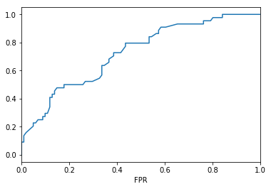

```python
import matplotlib.pyplot as plt
%matplotlib inline
ROC=model.stages[2].summary.roc
df=ROC.toPandas()

df.plot(x='FPR', y='TPR', legend=False)

#This model has good performance for the first 60% of most confident observations, and then very poor performance at trying to capture the last 40%.
```